# Lista 1

Author

Leonardo Ramos Barbosa - 211010360

Published

October 26, 2023

# Parte 1

### Exercício 1

1. Escreva uma equação matemática de sua escolha via LaTeX, utilizando o operador `$$`.

#### R:

Usamos a seguinte equação para calcular o somatório de `1` a `n`
$$\frac{n(n+1)}{2}$$

### Exercício 2

2. Defina um vetor `x` contendo uma sequência de 101 números. Em seguida, defina outro vetor `y` que seja o resultado da equação que escolheu no **Exercício 1** aplicada sobre o vertor `x` criado.

#### R:

```r
x <- seq(1, 101)
x
```

```
  [1]   1   2   3   4   5   6   7   8   9  10  11  12  13  14  15  16  17  18
 [19]  19  20  21  22  23  24  25  26  27  28  29  30  31  32  33  34  35  36
 [37]  37  38  39  40  41  42  43  44  45  46  47  48  49  50  51  52  53  54
 [55]  55  56  57  58  59  60  61  62  63  64  65  66  67  68  69  70  71  72
 [73]  73  74  75  76  77  78  79  80  81  82  83  84  85  86  87  88  89  90
 [91]  91  92  93  94  95  96  97  98  99 100 101
```

```r
y <- (x * (x + 1)) / 2
y
```

```
  [1]    1    3    6   10   15   21   28   36   45   55   66   78   91  105  120
 [16]  136  153  171  190  210  231  253  276  300  325  351  378  406  435  465
 [31]  496  528  561  595  630  666  703  741  780  820  861  903  946  990 1035
 [46] 1081 1128 1176 1225 1275 1326 1378 1431 1485 1540 1596 1653 1711 1770 1830
 [61] 1891 1953 2016 2080 2145 2211 2278 2346 2415 2485 2556 2628 2701 2775 2850
 [76] 2926 3003 3081 3160 3240 3321 3403 3486 3570 3655 3741 3828 3916 4005 4095
 [91] 4186 4278 4371 4465 4560 4656 4753 4851 4950 5050 5151
```

# Parte 2

### Exercício 3

3. Adicione um link para a página **Wikipedia** de alguma cidade/país que você gostaria de visitar.

#### R:

China

### Exercício 4

4. Escreva um breve texto explicando porque você gostaria de visitar a cidade do **Exercício 3** contendo uma palavra em itálico e uma palavra em negrito.

#### R:

A China é um país que me gera muita **curiosidade** pela sua cultura milenar, sua *culinária* e seu alto nível de desenvolvimento tecnológico alcançado em tão pouco tempo.

### Exercício 5

5. Adicione uma imagem da cidade escolhida no **Exercício 4**.

#### R:

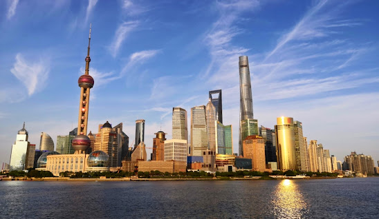

Shanghai, China

### Exercício 6

6. Adicione a mesma imagem do **Exercício 5**, mas com tamanho diferente.

#### R:

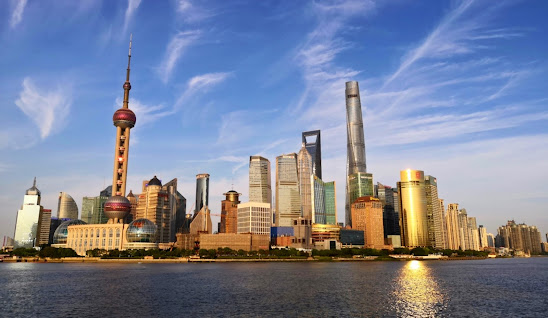

Shanghai, China

# Parte 3

### Exercício 7

7. Apresente apenas o comando (ou seja, sem mostrar a saída do código no documento html gerado) de como visualizar as primeiras 6 linhas do banco de dados `iris`.

#### R:

```r
head(iris)
```

### Exercício 8

8. Defina e apresente uma matriz numéria denominada `A` composta de 5 linhas e 5 colunas. **Dica:** use a função `runif()` para gerar os números que irão compor a matriz.

#### R:

```r
a <- matrix((runif(25, min=-10, max=10)), nrow=5, ncol=5)
a
```

```
            [,1]      [,2]      [,3]      [,4]      [,5]
[1,] -6.20304096 -9.321349 -1.890448  7.968862 -9.670414
[2,] -4.41289043 -2.132404 -7.651785  3.399970 -9.198482
[3,]  8.12882377  4.808001 -1.371739 -8.743442 -2.443617
[4,] -0.06489866  1.862071 -2.534808  2.647037 -7.459299
[5,] -1.66253475 -9.773976  4.980100 -2.320473 -3.208434
```

### Exercício 9

9. Calcule a inversa da matriz `A`.

#### R:

```r
a_inversa <- solve(a)
a_inversa
```

```
            [,1]        [,2]        [,3]        [,4]        [,5]
[1,]  0.34561530 -0.19907289  0.23483809 -0.19049365 -0.20694832
[2,] -0.19825898  0.03794674 -0.11593113  0.22088215  0.06353859
[3,] -0.13045969 -0.07194379 -0.10986129  0.23736644  0.13129289
[4,]  0.21383982 -0.14819204  0.05064674 -0.04434502 -0.15513996
[5,]  0.06771816 -0.01693551  0.02432245 -0.17366247 -0.08200764
```

### Exercício 10

10. Defina e apresente um objeto `R` em formato de *lista* contendo informações de 3 séries que tenha assistido. Especificamente, a primeira entrada da lista deve conter um vetor com o nome das séries escolhidas; o número de temporadas (até hoje) associado a cada série deve ser armazenado como um vetor na segunda entrada; por fim, a terceira entrada deverá armazenar um vetor lógico (T/F) indicando se você “maratonou” quando assistiu a respectiva série.

#### R:

```r
series <- list(c("Breaking Bad", "Mad Men", "The Office"),
               c(5, 7, 9),
               c(F, T, T))
series
```

```
[[1]]
[1] "Breaking Bad" "Mad Men"      "The Office"

[[2]]
[1] 5 7 9

[[3]]
[1] FALSE  TRUE  TRUE
```

### Exercício 11

11. Defina e apresente um conjunto de dados (objeto do tipo *data.frame*) contendo o nome dos 3 principais personagens de uma de suas séries favoritas na primeira coluna, a idade aproximada daquele personagem na série na segunda coluna e uma coluna que informa se o personagem morreu no decorrer da série.

#### R:

```r
chars <- data.frame(name = c("Michael Scott", "Jim Halpert", "Dwight Schrute"),
                    age = c(50, 37, 44),
                    died = c(FALSE, FALSE, FALSE))
chars
```

```
            name age  died
1  Michael Scott  50 FALSE
2    Jim Halpert  37 FALSE
3 Dwight Schrute  44 FALSE
```